# 2017-07-24 Notebook

Thinking about framing BAM in an ANOVA setting. There are two versions of this:

Manning:

$$4 \log W_{it} - 3 \log S_{it} = 10 \log (\delta A_{it} + A_{0, i}) - 6 \log N - 6 \log Q_t$$

The goal is to get this into a form familiar to ANOVA:

$$y_{it} = \mu + \alpha_i + \beta_t + \gamma_{it} + \epsilon_{it}$$
Already, we’re close. Some key assumptions and features of the ANOVA model must be adhered to. Namely:

- $\alpha_i$, $\beta_t$, and $\gamma_{it}$ all have mean zero (sum-to-zero constrained). If not, they are not *identifiable*. If we treat $A_0$ as the *median* area and $\delta A_{it}$ as the distance from the median area, then we have the nice feature that $E[\log(A_0)] = E[\log(A)]$ under the reasonable assumption that $\log(A)$ is symmetrically distributed.

$$4 \log W_{it} - 3 \log S_{it} = 10 \log (A_{0, i} + \delta A_{it}) - 6 \log N - 6 (\mu_q + \delta q_t)$$

Next we can use a Taylor series to (somewhat) split out $A_{0,i}$ from $\delta A_{it}$:

$$\log(A_{0, i} + \delta A_{it}) = log(A_{0, i}) + \sum_{j = 1}^\infty (-1)^{j - 1} \frac{\delta A_{it}^j}{A_{0, i}^j}$$

The first term on the RHS is indexed in $i$ only, and the second term is indexed in both $i$ and $t$. However, if the first term is known, then the second term is also known, and vice versa, since $\delta A_{it}$ is a measured variable. However, the first term does not sum to zero over the index $i$, although the second term *does* sum to zero over the double index $it$, under the assumption that $E[\log(A_{0,i})] = E[\log(A_{it})]$. Thus, using lowercase variables to represent log-transformed uppercase variables, we can write:

$$y_{it} = 4 w_{it} - 3 s_{it} = 10 (\mu_{a_0} + \delta a_{0,i}) + \gamma_{it} - 6 n - 6 (\mu_q + \delta q_t)$$

Here we have an ANOVA, where:

- $\mu = 10 \mu_{a_0} - 6n - 6 \mu_q$
- $\alpha_i = 10 \delta a_{0, i}$
- $\beta_t = -6 \delta q_t$
- $\gamma_{it} = \sum_{j = 1}^\infty (-1)^{j - 1} \frac{\delta A_{it}^j}{A_{0, i}^j}$

This hints at exactly what can be estimated via remote-sensed data in a BAM framework. Namely, we can estimate:

- $A_{0,i}$, to a proportionality
  - *but* can be estimated from $\gamma_{it}$, given it can be approximated linearly (more on that later)
- $Q_{t}$, to a proporionality

Two things are not clear to me at this point.

1. How well (if at all) can $\gamma_{it}$ be estimated, if there is an additional error term, $\epsilon_{it}$ present?
2. Assuming $\gamma_{it}$ *can* be estimated, is it possible to back out $A_{0, i}$
   - Under linear approximation of $\log(A)$? (I’m fairly certain it can)
   - Under quadratic, cubic, etc. approximation of $\log(A)$?

### Getting $A_{0, i}$ from linear approximation of $\log A$

If for each cross-section, I restrict the above calculation to use only values of $\delta A_{it}$ near the median (say, nothing greater than $2 * median(\delta A_{it}) - \min(\delta A_{it})$, then the linear approximation *should* be reasonable (but **I will need to check this further**).

### Changing topics: Computing resources

I’m curious as to how I might get some more computing power from my laptop. Specifically, can I ssh into a docker instance on my UMass computer?

Trying to go through VPN on my chromebook. Spoke w/ OIT, they’re not sure if I can. But otherwise I can go through ssl: https://sslvpn.umass.edu/dana-na/auth/url_default/welcome.cgi

- DONE. Via vpn in Chromebook bottom menu bar. Although for some reason this uses my old Spire password. Now to figure out a better alternative to Chrome remote desktop.
  - Using TeamViewer. Need to install on both chromebook and work computer.
  - Chrome remote desktop seems to work just fine after restarting UMass computer.

### Changing topics: Picking up on task list from 7/20-7/21.

- Make postprocessing functions
- Write tests
- Set up travis

Picking up where I left off on Friday, with `bayesplot` functions:

```r
load("cache/est1.RData")
posterior <- as.array(est1)

dim(posterior)
dimnames(posterior)[["parameters"]]
mcmc_intervals(posterior, pars = paste0("b[", 1:15, "]"))
mcmc_intervals(posterior, pars = c("logQc", "logWc"))
```

[output not shown]

Adding functions from previous work in SWOT R project.

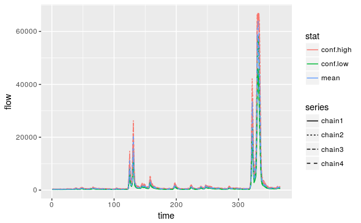

### Making minimal test datasets

```r
dim(Po_dA)
```

[output not shown]

Good. Added to inst/oneoff/datasets.R.

Now I can use this to see what pars I can prune from stanfit object.

```r
dimnames(pars)
```

```
$iterations
NULL

$chains
[1] "chain:1" "chain:2" "chain:3" "chain:4"

$parameters
 [1] "logQ[1]"       "logQ[2]"       "logQ[3]"       "logQ[4]"
 [5] "logQ[5]"       "logWc"         "logQc"         "b[1]"
 [9] "b[2]"          "amhg_rhs[1,1]" "amhg_rhs[2,1]" "amhg_rhs[1,2]"
[13] "amhg_rhs[2,2]" "amhg_rhs[1,3]" "amhg_rhs[2,3]" "amhg_rhs[1,4]"
[17] "amhg_rhs[2,4]" "amhg_rhs[1,5]" "amhg_rhs[2,5]" "lp__"
```

Some issue here with fitting. Trying a fix from [here](http://discourse.mc-stan.org/t/new-cppobject-xp-constructor-in-2-16-and-how-to-configure-travisci/1192/2). And recompiling.

- It worked!

### Thinking about project management

Git and github branch model: maybe something like described [here](http://nvie.com/posts/a-successful-git-branching-model/)